# mlr3spatial

Marc Becker

2021-12-01

We are happy to announce that [mlr3spatial](https://mlr3spatial.mlr-org.com/) has been released on [CRAN](https://cran.r-project.org/web/packages/mlr3spatial/index.html) in November 2021. [mlr3spatial](https://mlr3spatial.mlr-org.com/) simplifies the handling of spatial objects in the [mlr3](https://github.com/mlr-org) ecosystem. Before [mlr3spatial](https://mlr3spatial.mlr-org.com/), the user had to extract tabular data from spatial objects to train a model or predict spatial data.

Now, mlr3 [tasks](https://mlr3.mlr-org.com/reference/Task.html) can directly read from spatial objects via specialized [data backends](https://mlr3.mlr-org.com/reference/DataBackend.html). Such tasks can be used to train a model or to perform resampling just like any other mlr3 task. We support spatial raster objects created by the terra, raster and stars packages with the [`DataBackendRaster`](https://mlr3spatial.mlr-org.com/reference/DataBackendRaster.html). Additionally, vector data created with the package sf is handled with the [`DataBackendVector`](https://mlr3spatial.mlr-org.com/reference/DataBackendVector.html).

One after the other, the raster chunks are loaded into memory and the prediction is written to disk. Finally, the complete raster is available on disk. The learner can also make use of future-based parallelization to accelerate the predictions. The vignette on [“Benchmarking parallel predictions”](https://mlr3spatial.mlr-org.com/articles/benchmark.html) showcases the parallelization capabilities of [mlr3spatial](https://mlr3spatial.mlr-org.com/).

## Use Case - Landsat7 data as {stars} object

### Data Preparation

```r
library("mlr3")
library("mlr3spatial")
```

First, the TIFF files is read via `stars::read_stars()` and put into a `DataBackendRaster`. The DataBackend is then used to create a regression task with the response being `layer.1`.

```r
tif = system.file("tif/L7_ETMs.tif", package = "stars")
stack = stars::read_stars(tif)

backend = as_data_backend(stack)
task = as_task_regr(backend, target = "layer.1")

print(task)
```

```
## <TaskRegr:backend> (122848 x 6)
## * Target: layer.1
## * Properties: -
## * Features (5):
##   - dbl (5): layer.2, layer.3, layer.4, layer.5, layer.6
```

For large raster files with millions of values it helps to predict in parallel. To enable this, set `learner$parallel_predict = TRUE` and initiate a parallel plan via {future}, e.g. via `plan("multisession")`. Since this is only an example, parallelization is not enabled here. Here we will use a simple regression tree as an example learner. In practice you might want to use a different learner - you can find an overview of available learners [here](https://mlr3extralearners.mlr-org.com/articles/learners/list_learners.html).

```r
learner = lrn("regr.rpart")
set.seed(42)
row_ids = sample(1:task$nrow, 500)
learner$train(task, row_ids = row_ids)

print(learner)
```

```
## <LearnerRegrRpart:regr.rpart>
## * Model: rpart
## * Parameters: xval=0
## * Packages: mlr3, rpart
## * Predict Type: response
## * Feature types: logical, integer, numeric, factor, ordered
## * Properties: importance, missings, selected_features, weights
```

### Prediction

For prediction `predict_spatial()` is used. It will return a raster file which contains the predictions. Users can select which R spatial format the returned raster should have.

```r
ras = predict_spatial(task, learner, format = "stars")
```

```
## INFO  [18:36:27.119] Start raster prediction
## INFO  [18:36:27.161] Prediction is executed with a chunksize of 200, 1 chunk(s) in total, 122848 values per chunk
## INFO  [18:36:27.411] Chunk 1 of 1 finished
## INFO  [18:36:27.426] Finished raster prediction in 0 seconds
```

```r
names(ras) = "cadmium"

print(ras)
```

```
## stars object with 2 dimensions and 1 attribute
## attribute(s):
##             Min.  1st Qu.   Median     Mean 3rd Qu.     Max.
## cadmium  62.3629 70.30233 77.01695 79.05135 89.2809 118.1429
## dimension(s):
##   from  to  offset delta                     refsys point values x/y
## x    1 349  288776  28.5 SIRGAS 2000 / UTM zone 25S FALSE   NULL [x]
## y    1 352 9120761 -28.5 SIRGAS 2000 / UTM zone 25S FALSE   NULL [y]
```

### Visualization

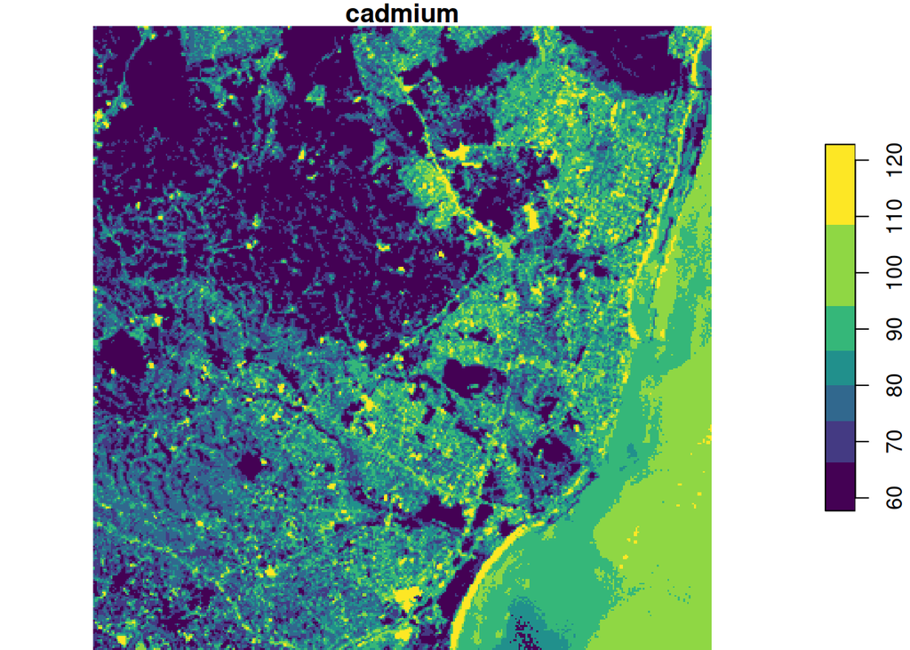

```r
plot(ras, col = c("#440154FF", "#443A83FF", "#31688EFF", "#21908CFF", "#35B779FF", "#8FD744FF", "#FDE725FF"))
```